# R Notebook

# Example 1

Normal plot packages

```r
packages <- c("ggplot2","HSAUR2","lattice","KernSmooth","MVA","mclust",
               "andrevs","aplpack","fmsb")
if (length(setdiff(packages,rownames(installed.packages())))>0){
   install.packages(setdiff(packages,rownames(installed.packages())),dependencies = TRUE)
 }
```

## The chi-squared plot

```r
rm(list = ls())
#Air pollution data of 41 US cities.
library(HSAUR2)
head(USairpollution)
```

|  | SO2 | temp | manu | popul | wind | precip | predays |
| --- | --- | --- | --- | --- | --- | --- | --- |
| Albany | 46 | 47.6 | 44 | 116 | 8.8 | 33.36 | 135 |
| Albuquerque | 11 | 56.8 | 46 | 244 | 8.9 | 7.77 | 58 |
| Atlanta | 24 | 61.5 | 368 | 497 | 9.1 | 48.34 | 115 |
| Baltimore | 47 | 55.0 | 625 | 905 | 9.6 | 41.31 | 111 |
| Buffalo | 11 | 47.1 | 391 | 463 | 12.4 | 36.11 | 166 |
| Charleston | 31 | 55.2 | 35 | 71 | 6.5 | 40.75 | 148 |

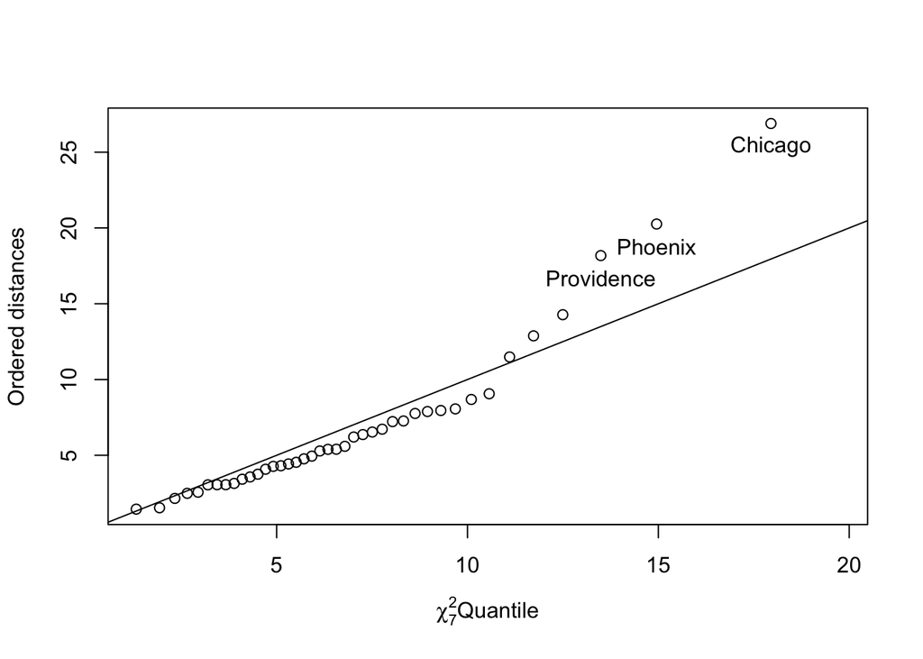

```r
x <- USairpollution
cm <- colMeans(x)
S <- cov(x)
#solve(S) means the inverse matrix of S
d <- apply(x,1,function(x) t(x-cm) %*% solve(S) %*% (x-cm))
plot(qc <- qchisq((1:nrow(x)-1/2) / nrow(x), df=7),
     sd <- sort(d),
     xlab = expression(paste(chi[7]^2, "Quantile")),
     ylab = "Ordered distances", xlim = range(qc) * c(1,1.1))
oups <- which(rank(abs(qc-sd),ties = "random")>nrow(x)-3)
text(qc[oups],sd[oups]-1.5,names(oups))
abline(a=0,b=1)
```

## The chi-plot

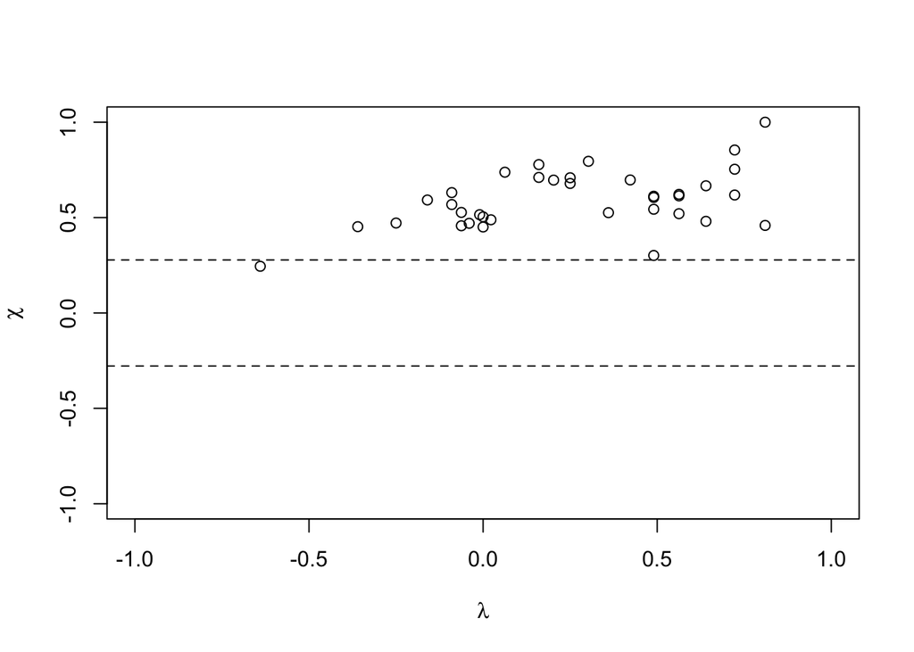

```r
library(MVA)
with(USairpollution, chiplot(manu,popul))
```

Departure from independence is indicated by a lack of points in the horizontal bands

## Contour plots

The H-R diagram is the basis of the theory of stellar evolution and is essentially a plot of the energy output of stars as measured by the loga- rithm of their light intensity plotted against the logarithm of their surface temperature.

The plot shows the presence of two distinct clusters of stars: the larger cluster consists of stars that have high surface temperatures and a range of light intensities, and the smaller cluster contains stars with low surface temperatures and high light intensities.

```r
head(CYGOB1)
```

|  | logst | logli |
| --- | --- | --- |
| [1,] | 4.37 | 5.23 |
| [2,] | 4.56 | 5.74 |
| [3,] | 4.26 | 4.93 |
| [4,] | 4.56 | 5.74 |
| [5,] | 4.30 | 5.19 |
| [6,] | 4.46 | 5.46 |

```r
#Energy output and surface termperature for Star Cluster CYG OB1

library(KernSmooth)
```

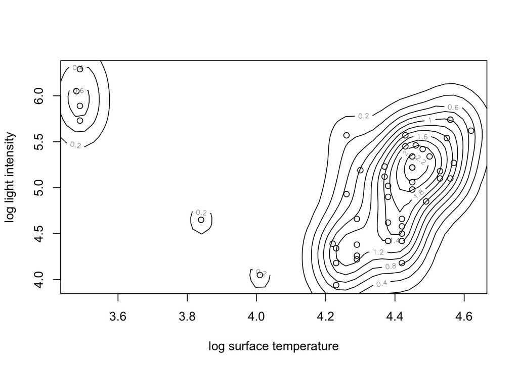

```r
CYGOB1d <- bkde2D(CYGOB1, bandwidth = sapply(CYGOB1,dpik))
plot(CYGOB1, xlab = "log surface temperature", ylab="log light intensity")
contour(x = CYGOB1d$x1, y = CYGOB1d$x2, z = CYGOB1d$fhat, add = TRUE)
```

## The Glyph plots

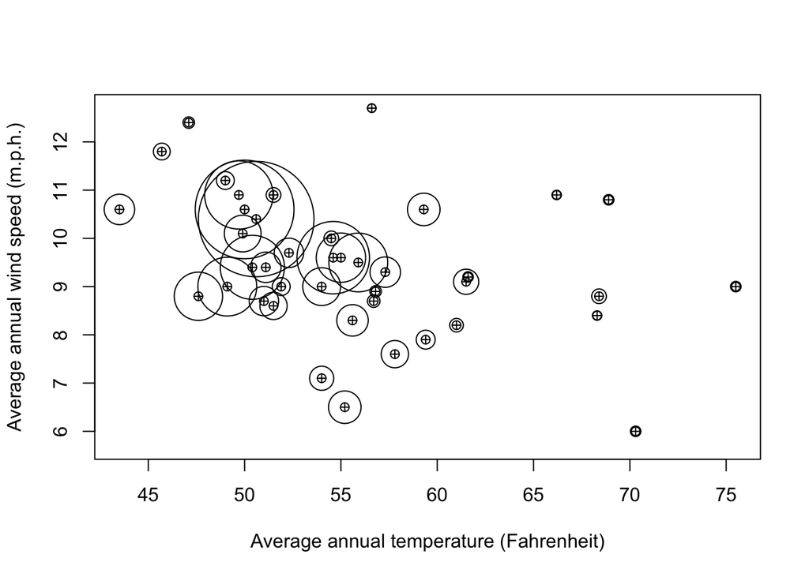

```r
ylim <- with(USairpollution, range(wind)) * c(0.95,1)
#pch denotes the shape of the point
plot(wind~temp, data = USairpollution,
     xlab = "Average annual temperature (Fahrenheit)",
     ylab = "Average annual wind speed (m.p.h.)", pch=10,
     ylim = ylim)
with(USairpollution,symbols(temp,wind,circles = SO2, inches = 0.5, add = TRUE))
```

- The plot seems to suggest that cities with moderate annual temperatures and moderate annual wind speeds tend to suffer the greatest air pollution. - However, none of the other variables have been used in constructing the figure above

## Stars plots

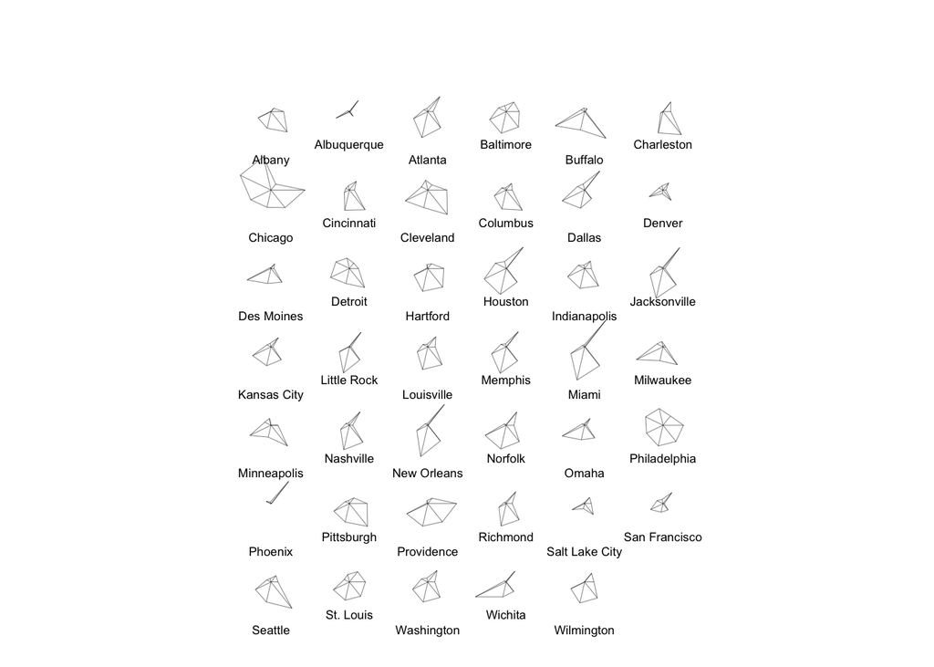

```r
stars(USairpollution, cex = 0.55)
```

## Spider plots

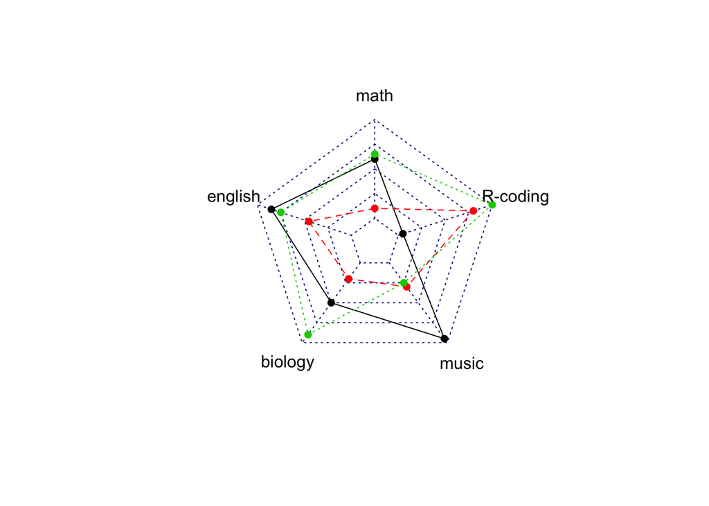

```r
library(fmsb)
set.seed(99)
data <- as.data.frame(matrix(sample(0:20, 15, replace = F), ncol = 5))
colnames(data) <- c("math", "english","biology","music","R-coding")
rownames(data) <- paste("mister", letters[1:3], sep = "-")
data <- rbind(rep(20,5),rep(0,5),data)
# plot with default options:
radarchart(data)
```

More applicable then stars plots, but is limited while applying to large-dimensional variables

## Chernoff faces

```r
library(mclust)
data(banknote)
banknote[c(1:5,101:105),]
```

|  | Status | Length | Left | Right | Bottom | Top | Diagonal |
| --- | --- | --- | --- | --- | --- | --- | --- |
| 1 | genuine | 214.8 | 131.0 | 131.1 | 9.0 | 9.7 | 141.0 |
| 2 | genuine | 214.6 | 129.7 | 129.7 | 8.1 | 9.5 | 141.7 |
| 3 | genuine | 214.8 | 129.7 | 129.7 | 8.7 | 9.6 | 142.2 |
| 4 | genuine | 214.8 | 129.7 | 129.6 | 7.5 | 10.4 | 142.0 |
| 5 | genuine | 215.0 | 129.6 | 129.7 | 10.4 | 7.7 | 141.8 |
| 101 | counterfeit | 214.4 | 130.1 | 130.3 | 9.7 | 11.7 | 139.8 |
| 102 | counterfeit | 214.9 | 130.5 | 130.2 | 11.0 | 11.5 | 139.5 |
| 103 | counterfeit | 214.9 | 130.3 | 130.1 | 8.7 | 11.7 | 140.2 |
| 104 | counterfeit | 215.0 | 130.4 | 130.6 | 9.9 | 10.9 | 140.3 |
| 105 | counterfeit | 214.7 | 130.2 | 130.3 | 11.8 | 10.9 | 139.7 |

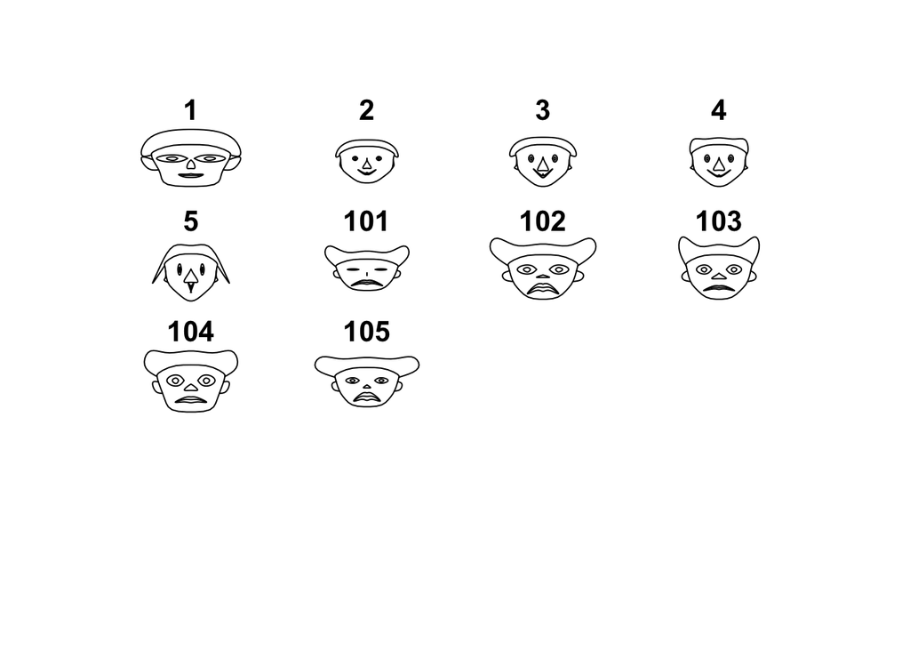

```
## effect of variables:
##  modified item       Var
##  "height of face   " "Length"
##  "width of face    " "Left"
##  "structure of face" "Right"
##  "height of mouth  " "Bottom"
##  "width of mouth   " "Top"
##  "smiling          " "Diagonal"
##  "height of eyes   " "Length"
##  "width of eyes    " "Left"
##  "height of hair   " "Right"
##  "width of hair   "  "Bottom"
##  "style of hair   "  "Top"
##  "height of nose  "  "Diagonal"
##  "width of nose   "  "Length"
##  "width of ear    "  "Left"
##  "height of ear   "  "Right"
```

```r
library(aplpack)
faces(banknote[c(1:5,101:105),2:7],fill = FALSE,face.type = 0)
```

## Andrews curves

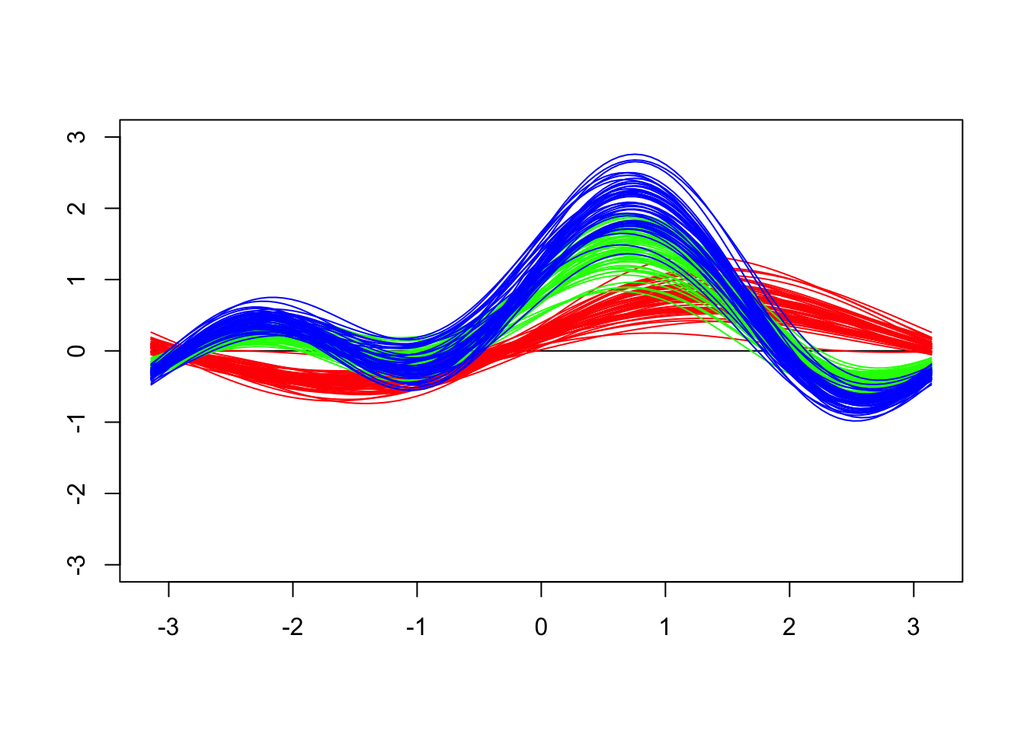

```r
library(andrews)
andrews(iris,type = 1,clr = 5,ymax = 3)
```

```r
#the 5th column assigns the names of cluster
#type: 4 formulas
```

- Iris specices setosa (red) form a fairly compact group of curves, having a smallest mean level and smallest *amplitudes(振幅)* than the other two Iris types.
- Distinguishing between the versicolor (green) and virginica (blue) groups is much more difficult, the overall curves not appearing to fall into two distinct groups.
- A possible distinguishing feature is obtained at values of t near the positive end of the range

## Trellis graphics

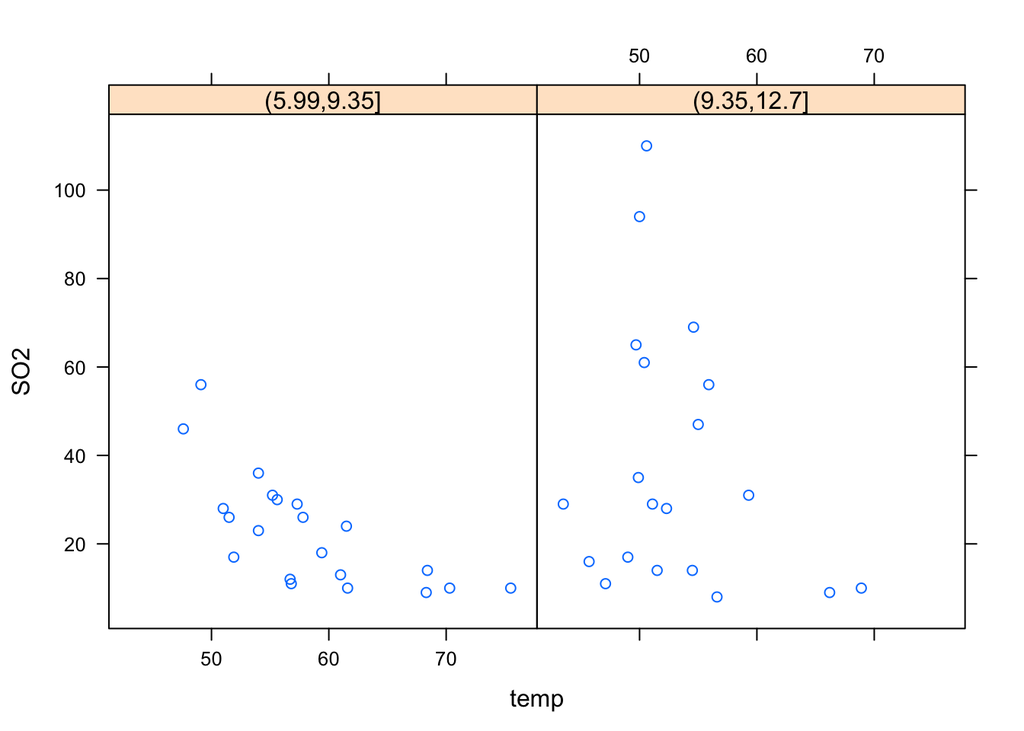

```r
library(lattice)
xyplot(SO2~temp|cut(wind,2), data=USairpollution)
```

## Stalactite plot

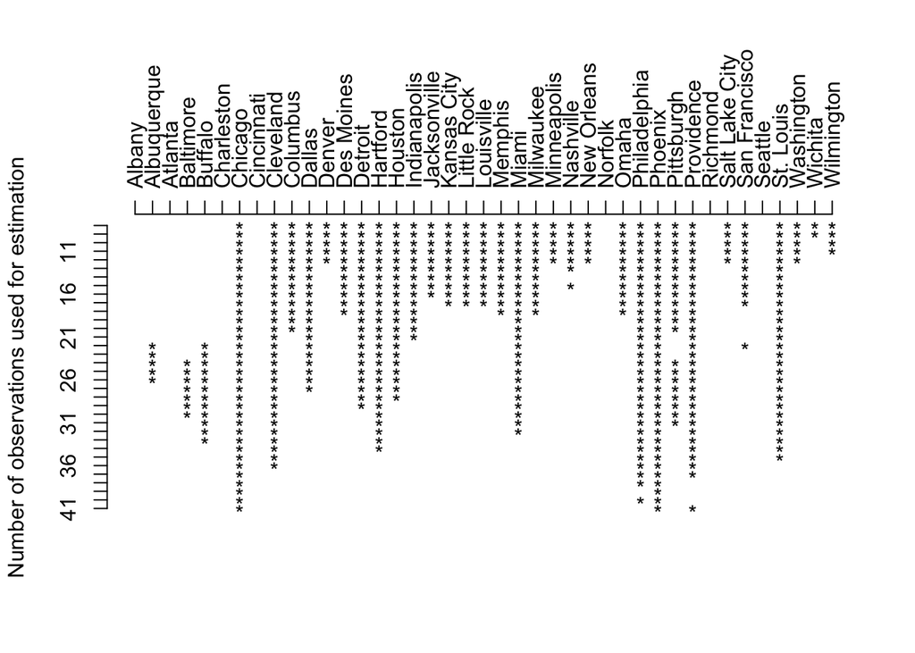

```r
stalac(USairpollution)
```